# Calcium-Binding Protein

Fold-switch pair **1jfkA_2nxqB** — **1jfkA** vs **2nxqB**

Entamoeba histolytica / Entamoeba histolytica HM-1:IMSS

## Figure 1: Phylogenetic tree with per-cluster fold-preference heatmap.

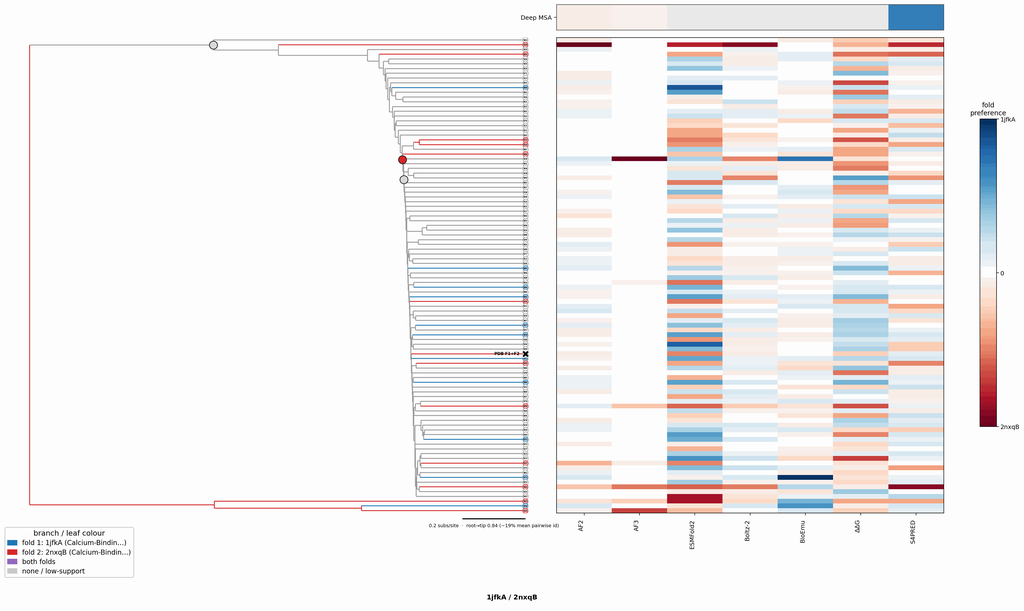

## Figure 2: Aligned overlay (both folds superposed)

The single fold-switching chain of each fold superposed by TM-align; waters hidden, any ligand shown as green sticks. Grey = structurally conserved core, colour = divergent (fold-switching) region. This pair switches fold coupled to oligomerisation; a single protomer is shown, not the full assembly.

1jfkA (Calcium-Binding Protein) · monomer2nxqB (Calcium-Binding Protein) · dimer

TM-score: 0.063 · Trigger class: oligomerization

Aligned overlay

Loading...

## Figure 3: The two folds, side by side

Each fold is coloured by per-residue Cα deviation between the two superposed structures: grey ≈ conserved core, full colour = structurally divergent (fold-switching) region.

1jfkA (Calcium-Binding Protein)

2nxqB (Calcium-Binding Protein)

0 Å5≥10 Å

1jfkA (Calcium-Binding Protein)

Loading...

2nxqB (Calcium-Binding Protein)

Loading...

## Figure 4: Best-cluster predicted contact maps over the two true folds.

Predicted contact maps (MSA-Transformer) for the clusters best matching each fold, over the true contacts of fold 1 (upper triangle) and fold 2 (lower). Divergent contacts between clusters are the contact-level signature of fold-switching.

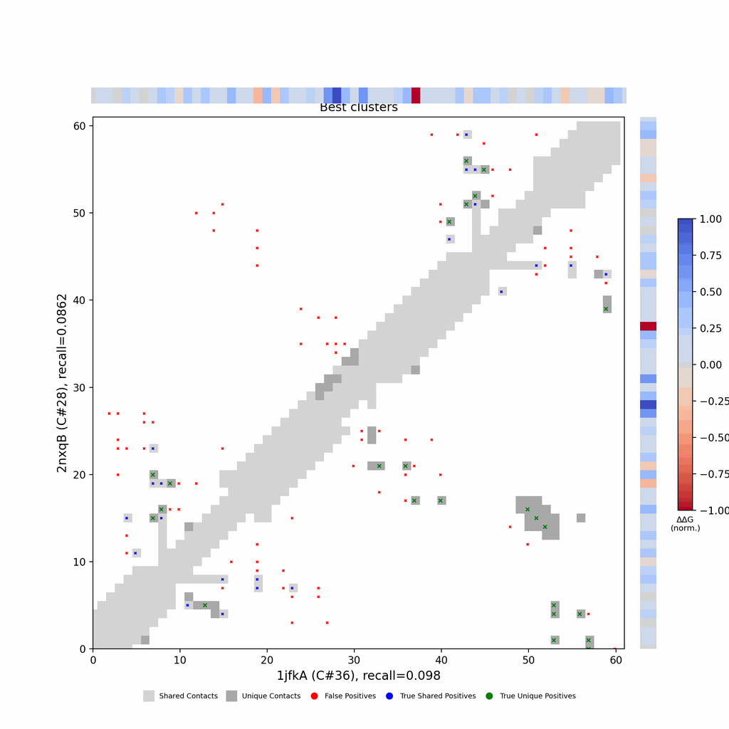

## Figure 5: Per-residue ΔΔG fold-preference contribution

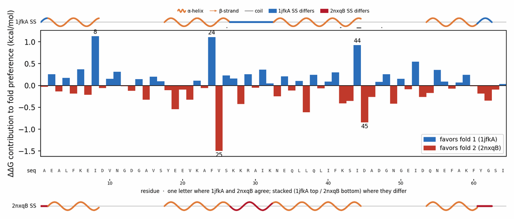

**More figures**

## Figure 6: Deep-MSA contact map panel / Best clusters contact map panel

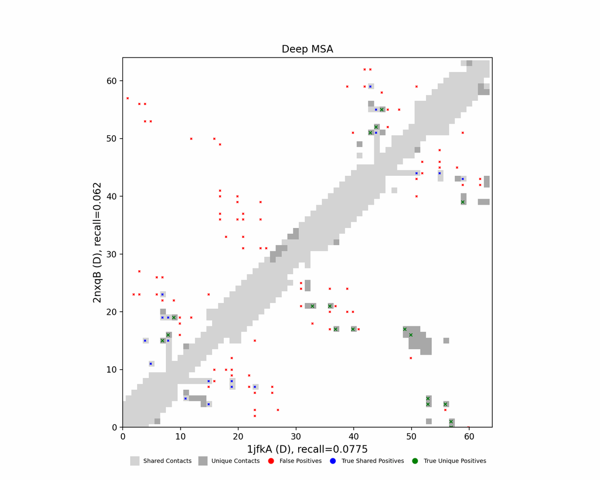

Deep-MSA contact map panel

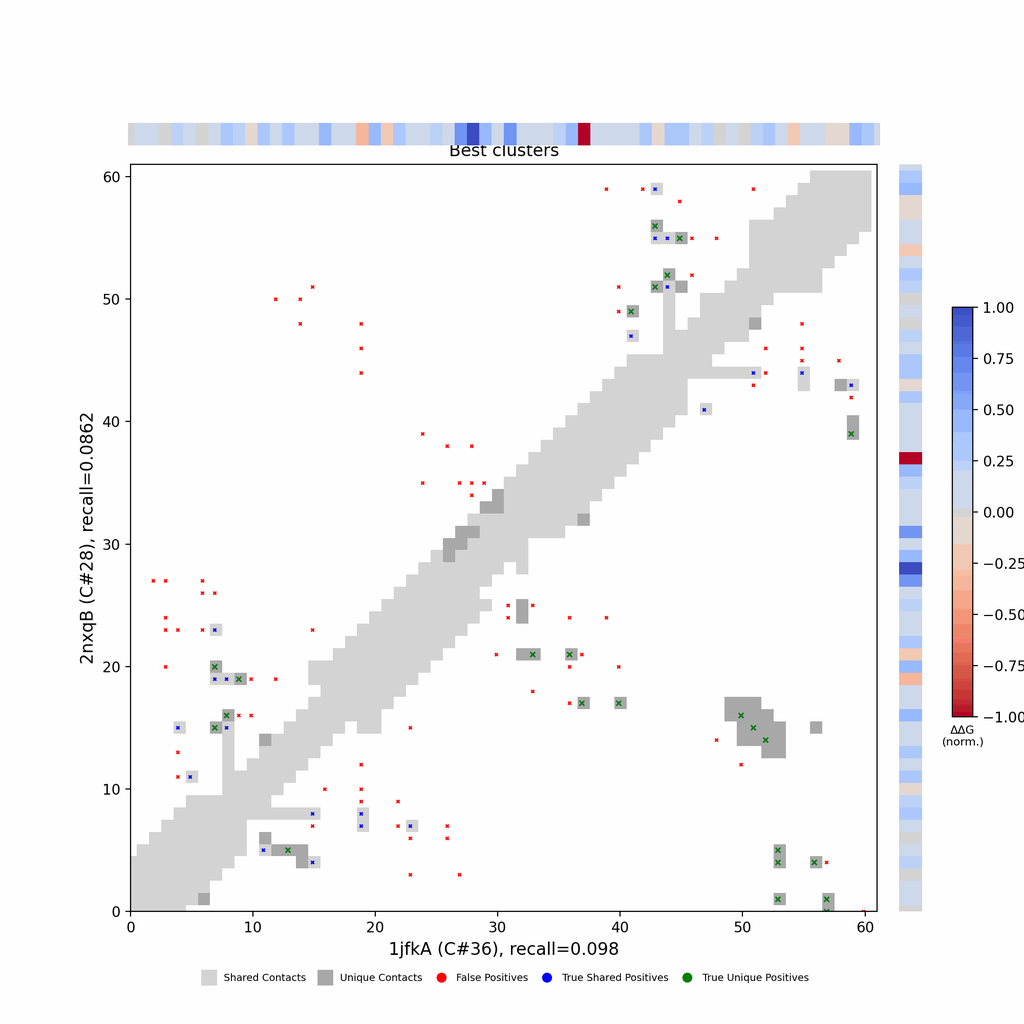

Best clusters contact map panel

## Figure 7: All clusters contact-map mosaic (small multiples).

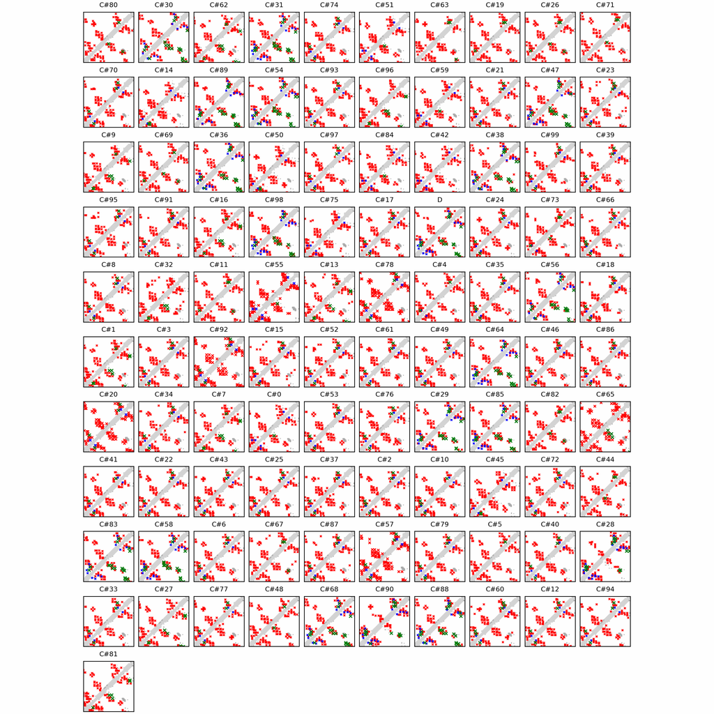

## Figure 8: Phylo null: tree with shuffled cluster fold labels.

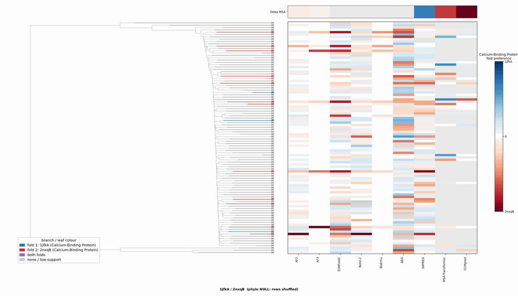

## Cluster metrics table

Per-cluster metrics underlying the figures above.

| cluster | n | neff | AF2_TM1 | AF2_TM2 | AF3_TM1 | AF3_TM2 | RE-MSAT-COM | RE-MSAT1 | RE-MSAT2 | ESM_SEQIDS | ESM_TM1 | ESM_TM2 | ΔΔG_Bias | ΔΔG_Bias_std | ΔΔG_frac_F1 | Boltz2_pref | S4PRED_pref | CCMpred_pref | BioEmu_pref |
| --- | --- | --- | --- | --- | --- | --- | --- | --- | --- | --- | --- | --- | --- | --- | --- | --- | --- | --- | --- |
| Deep | - | - | 0.45 | 0.47 | 0.45 | 0.46 | 0.25 | 0.36 | 0.35 | - | - | - | - | - | - | - | 0.02 | -0.14 | - |
| 000 | 825.0 | 756.0 | 0.47 | 0.46 | 0.44 | 0.46 | 0.07 | 0.05 | 0.06 | 001; 001; 003; 003; 007; 007; 004; 004; 005; 005 | 0.42 ± 0.03 | 0.52 ± 0.10 | -6.45 | 5.55 | 0.3 | -0.05 | 0.02 | -0.09 | -0.01 |
| 001 | 778.0 | 705.0 | 0.47 | 0.46 | 0.45 | 0.46 | 0.02 | 0.12 | 0.04 | 001; 001; 003; 002; 005; 003; 002; 005; 010; 010 | 0.43 ± 0.02 | 0.59 ± 0.16 | -6.72 | 6.02 | 0.3 | -0.08 | 0.02 | 0.02 | -0.01 |
| 002 | 574.0 | 511.0 | 0.46 | 0.45 | 0.45 | 0.46 | 0.05 | 0.06 | 0.13 | 008; 008; 001; 001; 004; 004; 002; 002; 003; 003 | 0.42 ± 0.03 | 0.53 ± 0.12 | -8.9 | 6.75 | 0.1 | -0.04 | 0.02 | -0.03 | -0.0 |
| 003 | 531.0 | 471.0 | 0.46 | 0.45 | 0.44 | 0.46 | 0.05 | 0.04 | 0.11 | 003; 003; 008; 008; 002; 002; 005; 007; 007; 005 | 0.47 ± 0.02 | 0.61 ± 0.09 | -6.15 | 4.98 | 0.0 | -0.07 | 0.03 | 0.02 | -0.0 |
| 004 | 463.0 | 422.0 | 0.46 | 0.45 | 0.45 | 0.46 | 0.02 | 0.02 | 0.07 | 007; 007; 008; 008; 002; 003; 006; 006; 002; 001 | 0.44 ± 0.03 | 0.46 ± 0.05 | -7.55 | 4.94 | 0.1 | -0.01 | 0.03 | 0.01 | -0.01 |
| 005 | 462.0 | 422.0 | 0.46 | 0.45 | 0.45 | 0.46 | 0.0 | 0.01 | 0.04 | 007; 007; 003; 003; 006; 006; 001; 001; 009; 009 | 0.46 ± 0.04 | 0.56 ± 0.16 | -7.88 | 5.8 | 0.1 | -0.06 | 0.0 | -0.03 | -0.0 |
| 006 | 377.0 | 332.0 | 0.46 | 0.46 | 0.45 | 0.46 | 0.05 | 0.06 | 0.13 | 002; 002; 006; 006; 003; 003; 009; 009; 004; 004 | 0.44 ± 0.03 | 0.53 ± 0.11 | -6.37 | 4.06 | 0.1 | -0.06 | 0.03 | 0.0 | -0.01 |
| 007 | 356.0 | 322.0 | 0.46 | 0.46 | 0.45 | 0.46 | 0.0 | 0.1 | 0.02 | 002; 002; 007; 007; 004; 004; 001; 001; 006; 003 | 0.42 ± 0.02 | 0.48 ± 0.05 | -6.93 | 5.34 | 0.1 | -0.03 | 0.02 | 0.01 | -0.0 |
| 008 | 349.0 | 313.0 | 0.46 | 0.46 | 0.44 | 0.45 | 0.05 | 0.06 | 0.12 | 009; 009; 003; 003; 001; 001; 002; 002; 004; 004 | 0.43 ± 0.02 | 0.55 ± 0.12 | -6.64 | 3.18 | 0.0 | -0.02 | 0.03 | 0.0 | -0.01 |
| 009 | 309.0 | 235.0 | 0.43 | 0.41 | 0.36 | 0.49 | 0.0 | 0.08 | 0.02 | 004; 004; 008; 008; 002; 002; 001; 001; 007; 003 | 0.44 ± 0.02 | 0.60 ± 0.17 | -8.69 | 5.87 | 0.1 | -0.16 | 0.03 | 0.01 | -0.01 |
| 010 | 309.0 | 278.0 | 0.47 | 0.45 | 0.45 | 0.46 | 0.05 | 0.05 | 0.11 | 003; 003; 005; 005; 001; 006; 001; 006; 008; 008 | 0.45 ± 0.01 | 0.63 ± 0.11 | -7.7 | 5.21 | 0.1 | -0.01 | 0.02 | 0.0 | -0.0 |
| 011 | 284.0 | 259.0 | 0.46 | 0.45 | 0.45 | 0.46 | 0.0 | 0.01 | 0.06 | 002; 002; 003; 003; 001; 004; 001; 004; 006; 006 | 0.40 ± 0.02 | 0.49 ± 0.03 | -3.14 | 5.59 | 0.2 | -0.11 | 0.02 | 0.0 | -0.0 |
| 012 | 281.0 | 263.0 | 0.47 | 0.45 | 0.45 | 0.46 | 0.05 | 0.04 | 0.11 | 003; 003; 006; 006; 008; 008; 001; 001; 010; 002 | 0.41 ± 0.02 | 0.48 ± 0.08 | -2.87 | 3.49 | 0.3 | -0.07 | 0.02 | 0.0 | -0.01 |
| 013 | 269.0 | 241.0 | 0.46 | 0.47 | 0.45 | 0.46 | 0.0 | 0.11 | 0.02 | 003; 003; 007; 007; 002; 004; 006; 006; 004; 002 | 0.45 ± 0.01 | 0.45 ± 0.04 | -2.6 | 4.11 | 0.3 | 0.0 | 0.03 | 0.01 | -0.01 |
| 014 | 256.0 | 234.0 | 0.47 | 0.46 | 0.45 | 0.46 | 0.05 | 0.06 | 0.05 | 002; 002; 001; 001; 004; 004; 006; 008; 003; 003 | 0.45 ± 0.03 | 0.53 ± 0.10 | -4.79 | 5.17 | 0.1 | -0.06 | 0.01 | 0.01 | -0.01 |
| 015 | 226.0 | 167.0 | 0.4 | 0.39 | 0.38 | 0.39 | 0.04 | 0.04 | 0.1 | 002; 002; 003; 007; 007; 003; 005; 001; 006; 001 | 0.46 ± 0.01 | 0.54 ± 0.09 | -9.18 | 6.63 | 0.2 | 0.06 | 0.03 | 0.0 | -0.02 |
| 016 | 222.0 | 206.0 | 0.47 | 0.46 | 0.45 | 0.46 | 0.0 | 0.08 | 0.02 | 003; 003; 004; 004; 001; 009; 007; 005; 001; 009 | 0.41 ± 0.03 | 0.60 ± 0.08 | -3.74 | 6.15 | 0.4 | -0.04 | 0.01 | 0.0 | -0.01 |
| 017 | 202.0 | 178.0 | 0.46 | 0.46 | 0.45 | 0.46 | 0.05 | 0.04 | 0.1 | 005; 005; 006; 006; 001; 004; 001; 004; 009; 009 | 0.44 ± 0.03 | 0.47 ± 0.08 | -4.38 | 3.83 | 0.2 | -0.06 | 0.02 | 0.0 | -0.0 |
| 018 | 200.0 | 69.0 | 0.4 | 0.36 | 0.44 | 0.89 | 0.05 | 0.04 | 0.12 | 008; 008; 001; 003; 003; 004; 004; 009; 001; 009 | 0.44 ± 0.01 | 0.47 ± 0.10 | -4.14 | 3.97 | 0.3 | -0.27 | 0.02 | 0.0 | 0.03 |
| 019 | 195.0 | 178.0 | 0.46 | 0.45 | 0.44 | 0.46 | 0.0 | 0.0 | 0.07 | 001; 001; 002; 002; 006; 006; 004; 004; 005; 005 | 0.44 ± 0.02 | 0.58 ± 0.03 | -0.67 | 2.71 | 0.5 | 0.04 | 0.03 | 0.0 | -0.01 |
| 020 | 195.0 | 183.0 | 0.45 | 0.46 | 0.45 | 0.46 | 0.05 | 0.05 | 0.11 | 005; 005; 006; 006; 004; 004; 003; 003; 009; 009 | 0.43 ± 0.03 | 0.46 ± 0.04 | -1.37 | 2.55 | 0.3 | -0.08 | 0.03 | 0.0 | -0.0 |
| 021 | 181.0 | 169.0 | 0.47 | 0.46 | 0.45 | 0.46 | 0.05 | 0.04 | 0.11 | - | - | - | -6.26 | 6.11 | 0.1 | -0.05 | 0.03 | - | -0.01 |
| 022 | 180.0 | 166.0 | 0.47 | 0.46 | 0.45 | 0.46 | 0.05 | 0.04 | 0.1 | - | - | - | -2.05 | 2.55 | 0.3 | -0.02 | 0.03 | - | -0.01 |
| 023 | 175.0 | 160.0 | 0.47 | 0.47 | 0.45 | 0.46 | 0.06 | 0.05 | 0.12 | - | - | - | -0.28 | 1.58 | 0.7 | -0.02 | 0.03 | - | -0.0 |
| 024 | 174.0 | 104.0 | 0.25 | 0.48 | 0.45 | 0.46 | 0.06 | 0.06 | 0.13 | - | - | - | -5.96 | 3.82 | 0.0 | -0.46 | -0.0 | - | -0.01 |
| 025 | 168.0 | 135.0 | 0.45 | 0.46 | 0.44 | 0.46 | 0.05 | 0.05 | 0.11 | - | - | - | -4.79 | 3.66 | 0.1 | -0.05 | 0.03 | - | -0.0 |
| 026 | 167.0 | 144.0 | 0.46 | 0.46 | 0.44 | 0.46 | 0.0 | 0.02 | 0.06 | - | - | - | -4.72 | 6.47 | 0.4 | -0.07 | 0.03 | - | -0.0 |
| 027 | 166.0 | 147.0 | 0.46 | 0.45 | 0.44 | 0.45 | 0.0 | 0.11 | 0.0 | - | - | - | -4.25 | 4.97 | 0.3 | -0.03 | 0.03 | - | -0.01 |
| 028 | 157.0 | 139.0 | 0.46 | 0.46 | 0.45 | 0.46 | 0.35 | 0.23 | 0.48 | - | - | - | -3.22 | 5.09 | 0.2 | -0.12 | 0.02 | - | -0.01 |

[output cut: 71 more lines]